# Titanic -- Mohit

```python
import pandas as pd
import numpy as np

import seaborn as sns
from matplotlib import pyplot as plt
%matplotlib inline

import warnings
warnings.filterwarnings('ignore')
```

```python
data=pd.read_table("train.csv", sep=",")
```

```python
data.shape
data.info()
```

```
<class 'pandas.core.frame.DataFrame'>
RangeIndex: 891 entries, 0 to 890
Data columns (total 12 columns):
PassengerId    891 non-null int64
Survived       891 non-null int64
Pclass         891 non-null int64
Name           891 non-null object
Sex            891 non-null object
Age            714 non-null float64
SibSp          891 non-null int64
Parch          891 non-null int64
Ticket         891 non-null object
Fare           891 non-null float64
Cabin          204 non-null object
Embarked       889 non-null object
dtypes: float64(2), int64(5), object(5)
memory usage: 83.6+ KB
```

The Age, Cabin and Embarked have null values. I will try to fix them.

```python
data.isnull().sum()
```

```
PassengerId      0
Survived         0
Pclass           0
Name             0
Sex              0
Age            177
SibSp            0
Parch            0
Ticket           0
Fare             0
Cabin          687
Embarked         2
dtype: int64
```

```python
data.head()
```

|  | PassengerId | Survived | Pclass | Name | Sex | Age | SibSp | Parch | Ticket | Fare | Cabin | Embarked |
| --- | --- | --- | --- | --- | --- | --- | --- | --- | --- | --- | --- | --- |
| 0 | 1 | 0 | 3 | Braund, Mr. Owen Harris | male | 22.0 | 1 | 0 | A/5 21171 | 7.2500 | NaN | S |
| 1 | 2 | 1 | 1 | Cumings, Mrs. John Bradley (Florence Briggs Th... | female | 38.0 | 1 | 0 | PC 17599 | 71.2833 | C85 | C |
| 2 | 3 | 1 | 3 | Heikkinen, Miss. Laina | female | 26.0 | 0 | 0 | STON/O2. 3101282 | 7.9250 | NaN | S |
| 3 | 4 | 1 | 1 | Futrelle, Mrs. Jacques Heath (Lily May Peel) | female | 35.0 | 1 | 0 | 113803 | 53.1000 | C123 | S |
| 4 | 5 | 0 | 3 | Allen, Mr. William Henry | male | 35.0 | 0 | 0 | 373450 | 8.0500 | NaN | S |

```python
data.Survived.value_counts()
```

```
0    549
1    342
Name: Survived, dtype: int64
```

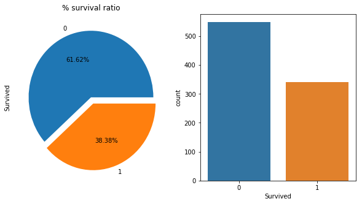

```python
f,ax=plt.subplots(1,2,figsize=(10,5))
data.Survived.value_counts().plot.pie(explode=[0,.1], autopct='%0.2f%%',ax=ax[0] )
ax[0].set_title("% survival ratio")

sns.countplot(data=data, x="Survived", ax=ax[1])
```

It is evident that not many passengers survived the accident.

Out of 891 passengers in training set, only around 350 survived i.e Only 38.4% of the total training set survived the crash. We need to dig down more to get better insights from the data and see which categories of the passengers did survive and who didn't.

We will try to check the survival rate by using the different features of the dataset. Some of the features being Sex, Port Of Embarcation, Age,etc.

First let us understand the different types of features.

## Types Of Features

### Categorical Features:

A categorical variable is one that has two or more categories and each value in that feature can be categorised by them.For example, gender is a categorical variable having two categories (male and female). Now we cannot sort or give any ordering to such variables. They are also known as Nominal Variables.

Categorical Features in the dataset: Sex,Embarked.

### Ordinal Features:

An ordinal variable is similar to categorical values, but the difference between them is that we can have relative ordering or sorting between the values. For eg: If we have a feature like Height with values Tall, Medium, Short, then Height is a ordinal variable. Here we can have a relative sort in the variable.

Ordinal Features in the dataset: PClass

### Continous Feature:

A feature is said to be continous if it can take values between any two points or between the minimum or maximum values in the features column.

Continous Features in the dataset: Age

```
Text(0.5,1,u'Survived distribution')
```

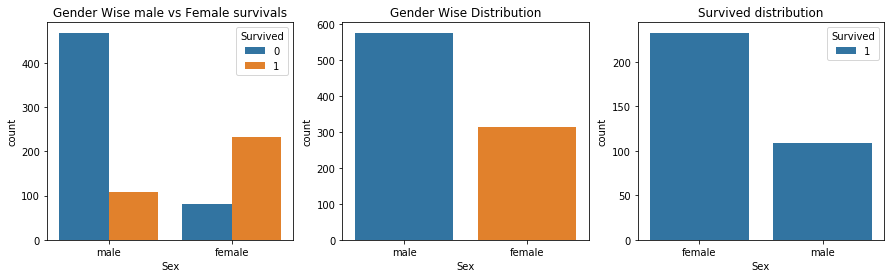

```python
f,ax=plt.subplots(1,3,figsize=(15,4))
sns.countplot("Sex", hue="Survived",data=data,ax=ax[0])
ax[0].set_title("Gender Wise male vs Female survivals")

sns.countplot("Sex", data=data, ax=ax[1])
ax[1].set_title("Gender Wise Distribution")

sns.countplot("Sex", hue="Survived", data=data[data["Survived"]==1], ax=ax[2])
ax[2].set_title("Survived distribution")
```

```python
pd.crosstab(data.Sex, data.Survived, margins=True).style.background_gradient(cmap='summer_r')
```

| Survived Sex | 0 | 1 | All |
| --- | --- | --- | --- |
| female | 81 | 233 | 314 |
| male | 468 | 109 | 577 |
| All | 549 | 342 | 891 |

This looks interesting. The number of men on the ship is lot more than the number of women. Still the number of women saved is almost twice the number of males saved. The survival rates for a women on the ship is around 75% while that for men in around 18-19%.

This looks to be a very important feature for modeling. But is it the best?? Lets check other features.

### PClass

```python
pd.crosstab(data.Pclass, data.Survived).style.background_gradient(cmap='summer_r')
```

| Survived Pclass | 0 | 1 |
| --- | --- | --- |
| 1 | 80 | 136 |
| 2 | 97 | 87 |
| 3 | 372 | 119 |

```
Text(0.5,1,u'Survived by class')
```

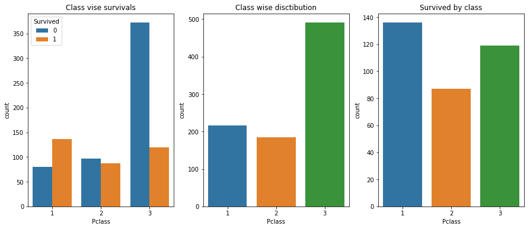

```python
f,ax=plt.subplots(1,3,figsize=(15,6))
sns.countplot("Pclass", hue="Survived", data=data, ax=ax[0])
ax[0].set_title("Class vise survivals")
sns.countplot("Pclass", data=data, ax=ax[1])
ax[1].set_title("Class wise disctibution")

sns.countplot("Pclass", data=data[data.Survived==1], ax=ax[2])
ax[2].set_title("Survived by class")
```

People say Money Can't Buy Everything. But we can clearly see that Passenegers Of Pclass 1 were given a very high priority while rescue. Even though the the number of Passengers in Pclass 3 were a lot higher, still the number of survival from them is very low, somewhere around 25%.

For Pclass 1 %survived is around 63% while for Pclass2 is around 48%. So money and status matters. Such a materialistic world.

Lets Dive in little bit more and check for other interesting observations. Lets check survival rate with Sex and Pclass Together.

```python
pd.crosstab((data.Pclass, data.Sex),data.Survived).style.background_gradient(cmap='summer_r')
```

| Pclass | Survived Sex | 0 | 1 |
| --- | --- | --- | --- |
| 1 | female | 3 | 91 |
|  | male | 77 | 45 |
| 2 | female | 6 | 70 |
|  | male | 91 | 17 |
| 3 | female | 72 | 72 |
|  | male | 300 | 47 |

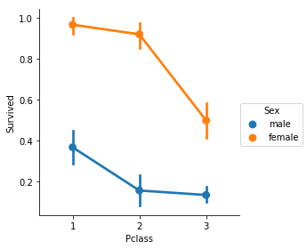

```python
sns.factorplot('Pclass','Survived', hue='Sex', data=data)
```

We use FactorPlot in this case, because they make the seperation of categorical values easy.

Looking at the CrossTab and the FactorPlot, we can easily infer that survival for Women from Pclass1 is about 95-96%, as only 3 out of 94 Women from Pclass1 died.

It is evident that irrespective of Pclass, Women were given first priority while rescue. Even Men from Pclass1 have a very low survival rate.

Looks like Pclass is also an important feature. Lets analyse other features.

### Age (Continious Variable)

```python
print "Oldest person Age is ", data.Age.max(), "%"
print "Youngest person Age is ", data.Age.min(), "%"
print "Mean age is ", data.Age.mean(), "%"
print "missing count ", data.Age.isnull().sum()
```

```
Oldest person Age is  80.0 %
Youngest person Age is  0.42 %
Mean age is  29.6991176471 %
missing count  177
```

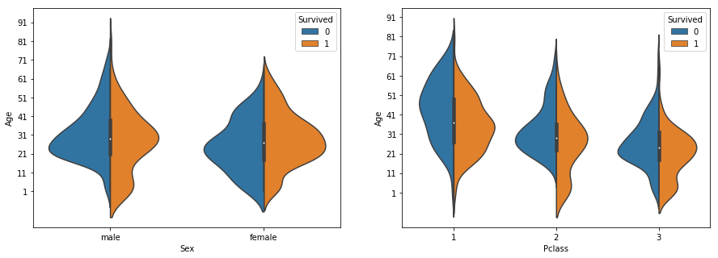

```python
f,ax=plt.subplots(1,2,figsize=(15,5))
sns.violinplot("Sex","Age",hue="Survived", data=data, split=True, ax=ax[0])
ax[0].set_yticks(range(1,100,10))
sns.violinplot("Pclass","Age",hue="Survived", data=data, split=True,ax=ax[1])
ax[1].set_yticks(range(1,100,10))
```

### Observations:

1)The number of children increases with Pclass and the survival rate for passenegers below Age 10(i.e children) looks to be good irrespective of the Pclass.

2)Survival chances for Passenegers aged 20-50 from Pclass1 is high and is even better for Women.

3)For males, the survival chances decreases with an increase in age.

As we had seen earlier, the Age feature has 177 null values. To replace these NaN values, we can assign them the mean age of the dataset.

But the problem is, there were many people with many different ages. We just cant assign a 4 year kid with the mean age that is 29 years. Is there any way to find out what age-band does the passenger lie??

Bingo!!!!, we can check the Name feature. Looking upon the feature, we can see that the names have a salutation like Mr or Mrs. Thus we can assign the mean values of Mr and Mrs to the respective groups.

```python
data.head()
```

|  | PassengerId | Survived | Pclass | Name | Sex | Age | SibSp | Parch | Ticket | Fare | Cabin | Embarked |
| --- | --- | --- | --- | --- | --- | --- | --- | --- | --- | --- | --- | --- |
| 0 | 1 | 0 | 3 | Braund, Mr. Owen Harris | male | 22.0 | 1 | 0 | A/5 21171 | 7.2500 | NaN | S |
| 1 | 2 | 1 | 1 | Cumings, Mrs. John Bradley (Florence Briggs Th... | female | 38.0 | 1 | 0 | PC 17599 | 71.2833 | C85 | C |
| 2 | 3 | 1 | 3 | Heikkinen, Miss. Laina | female | 26.0 | 0 | 0 | STON/O2. 3101282 | 7.9250 | NaN | S |
| 3 | 4 | 1 | 1 | Futrelle, Mrs. Jacques Heath (Lily May Peel) | female | 35.0 | 1 | 0 | 113803 | 53.1000 | C123 | S |
| 4 | 5 | 0 | 3 | Allen, Mr. William Henry | male | 35.0 | 0 | 0 | 373450 | 8.0500 | NaN | S |

```python
data.info()
```

[output not shown]

```python
data.Initial.value_counts()
```

[output not shown]

```python
data.Initial=data['Initial'].replace(['Mlle','Mme','Ms','Dr','Major','Lady','Countess','Jonkheer','Col','Rev','Capt','Sir','Don'],['Miss','Miss','Miss','Mr','Mr','Mrs','Mrs','Other','Other','Other','Mr','Mr','Mr'])
```

```python
data.Initial.value_counts()
```

```
Mr        529
Miss      186
Mrs       127
Master     40
Other       9
Name: Initial, dtype: int64
```

```python
pd.crosstab(data.Initial, data.Survived).T
```

| Initial Survived | Master | Miss | Mr | Mrs | Other |
| --- | --- | --- | --- | --- | --- |
| 0 | 17 | 55 | 443 | 26 | 8 |
| 1 | 23 | 131 | 86 | 101 | 1 |

```python
data.groupby("Initial")["Age"].mean()
```

```
Initial
Master     4.574167
Miss      21.860000
Mr        32.739609
Mrs       35.981818
Other     45.888889
Name: Age, dtype: float64
```

```python
## Assigning the NaN Values with the Ceil values of the mean ages
data.loc[(data.Age.isnull())&(data.Initial=='Mr'),'Age']=33
data.loc[(data.Age.isnull())&(data.Initial=='Mrs'),'Age']=36
data.loc[(data.Age.isnull())&(data.Initial=='Master'),'Age']=5
data.loc[(data.Age.isnull())&(data.Initial=='Miss'),'Age']=22
data.loc[(data.Age.isnull())&(data.Initial=='Other'),'Age']=46
```

```python
data.Age.isnull().any() #So no null values left finally
```

```
False
```

```python
data.isnull().sum()
```

```
PassengerId      0
Survived         0
Pclass           0
Name             0
Sex              0
Age              0
SibSp            0
Parch            0
Ticket           0
Fare             0
Cabin          687
Embarked         2
Initial          0
dtype: int64
```

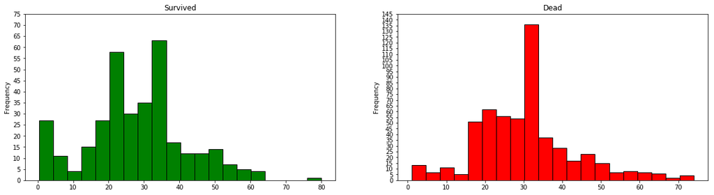

```python
f,ax=plt.subplots(1,2,figsize=(20,5))
data[data.Survived==1].Age.plot.hist(edgecolor='black',color='green',bins=20,ax=ax[0])
ax[0].set_title("Survived")
ax[0].set_yticks(range(0,80,5))
data[data.Survived==0].Age.plot.hist(edgecolor='black',color='r',bins=20,ax=ax[1])
ax[1].set_title("Dead")
ax[1].set_yticks(range(0,150,5))
```

### Observations:

1)The Toddlers(age<5) were saved in large numbers(The Women and Child First Policy).

2)The oldest Passenger was saved(80 years).

3)Maximum number of deaths were in the age group of 30-40.

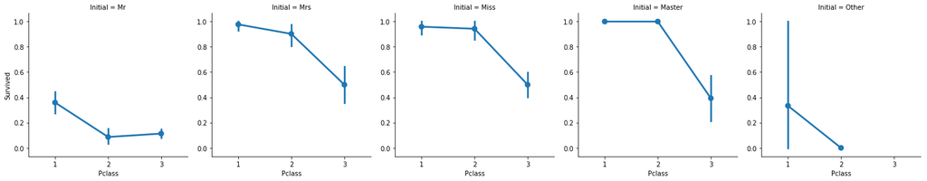

```python
sns.factorplot("Pclass","Survived", col="Initial", data=data)
```

The Women and Child first policy thus holds true irrespective of the class.

### Embarked--> Categorical Value

```python
pd.crosstab((data.Embarked,data.Pclass),[data.Survived,data.Sex],margins=True).style.background_gradient(cmap='summer_r')
```

| Embarked | Survived Sex Pclass | 0 female | 0 male | 1 female | 1 male | All |
| --- | --- | --- | --- | --- | --- | --- |
| C | 1 | 1 | 25 | 42 | 17 | 85 |
|  | 2 | 0 | 8 | 7 | 2 | 17 |
|  | 3 | 8 | 33 | 15 | 10 | 66 |
| Q | 1 | 0 | 1 | 1 | 0 | 2 |
|  | 2 | 0 | 1 | 2 | 0 | 3 |
|  | 3 | 9 | 36 | 24 | 3 | 72 |
| S | 1 | 2 | 51 | 46 | 28 | 127 |
|  | 2 | 6 | 82 | 61 | 15 | 164 |
|  | 3 | 55 | 231 | 33 | 34 | 353 |
| All |  | 81 | 468 | 231 | 109 | 889 |

```
Text(0.5,1,u'Sex v/s Embark')
```

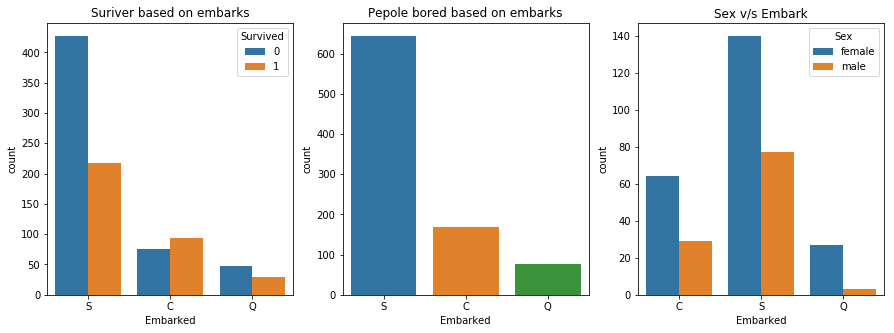

```python
f,ax=plt.subplots(1,3,figsize=(15,5))
sns.countplot("Embarked",hue="Survived", data=data, ax=ax[0])
ax[0].set_title("Suriver based on embarks")
sns.countplot("Embarked", data=data, ax=ax[1])
ax[1].set_title("Pepole bored based on embarks")
sns.countplot("Embarked", hue="Sex", data=data[data.Survived==1], ax=ax[2])
ax[2].set_title("Sex v/s Embark")
```

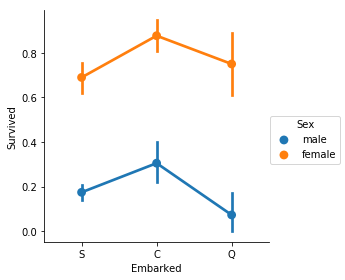

```python
sns.factorplot("Embarked", "Survived",hue="Sex", data=data)
```

Observations:

1)Maximum passenegers boarded from S. Majority of them being from Pclass3.

2)The Passengers from C look to be lucky as a good proportion of them survived. The reason for this maybe the rescue of all the Pclass1 and Pclass2 Passengers.

3)The Embark S looks to the port from where majority of the rich people boarded. Still the chances for survival is low here, that is because many passengers from Pclass3 around 81% didn't survive.

4)Port Q had almost 95% of the passengers were from Pclass3.

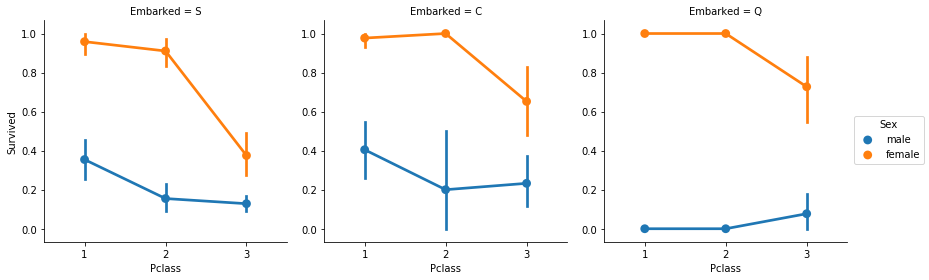

```python
sns.factorplot("Pclass","Survived",hue="Sex", col='Embarked',data=data)
```

Observations:

1)The survival chances are almost 1 for women for Pclass1 and Pclass2 irrespective of the Pclass.

2)Port S looks to be very unlucky for Pclass3 Passenegers as the survival rate for both men and women is very low.(Money Matters)

3)Port Q looks looks to be unlukiest for Men, as almost all were from Pclass 3.

### Filling Embarked NaN

As we saw that maximum passengers boarded from Port S, we replace NaN with S.

```python
data.Embarked.fillna("S",inplace=True)
```

```python
data.Embarked.isnull().sum()
```

```
0
```

### SibSip-->Discrete Feature

```python
data.head()
```

|  | PassengerId | Survived | Pclass | Name | Sex | Age | SibSp | Parch | Ticket | Fare | Cabin | Embarked | Initial |
| --- | --- | --- | --- | --- | --- | --- | --- | --- | --- | --- | --- | --- | --- |
| 0 | 1 | 0 | 3 | Braund, Mr. Owen Harris | male | 22.0 | 1 | 0 | A/5 21171 | 7.2500 | NaN | S | Mr |
| 1 | 2 | 1 | 1 | Cumings, Mrs. John Bradley (Florence Briggs Th... | female | 38.0 | 1 | 0 | PC 17599 | 71.2833 | C85 | C | Mrs |
| 2 | 3 | 1 | 3 | Heikkinen, Miss. Laina | female | 26.0 | 0 | 0 | STON/O2. 3101282 | 7.9250 | NaN | S | Miss |
| 3 | 4 | 1 | 1 | Futrelle, Mrs. Jacques Heath (Lily May Peel) | female | 35.0 | 1 | 0 | 113803 | 53.1000 | C123 | S | Mrs |
| 4 | 5 | 0 | 3 | Allen, Mr. William Henry | male | 35.0 | 0 | 0 | 373450 | 8.0500 | NaN | S | Mr |

```python
data.SibSp.value_counts()
```

```
0    608
1    209
2     28
4     18
3     16
8      7
5      5
Name: SibSp, dtype: int64
```

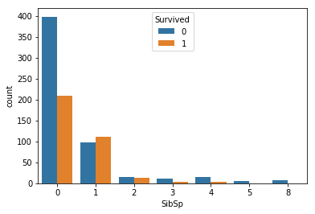

```python
sns.countplot("SibSp", hue="Survived",data=data)
```

This feature represents whether a person is alone or with his family members.

Sibling = brother, sister, stepbrother, stepsister

Spouse = husband, wife

```python
pd.crosstab(data.SibSp,data.Survived, margins=True).style.background_gradient(cmap='summer_r')
```

| Survived SibSp | 0 | 1 | All |
| --- | --- | --- | --- |
| 0 | 398 | 210 | 608 |
| 1 | 97 | 112 | 209 |
| 2 | 15 | 13 | 28 |
| 3 | 12 | 4 | 16 |
| 4 | 15 | 3 | 18 |
| 5 | 5 | 0 | 5 |
| 8 | 7 | 0 | 7 |
| All | 549 | 342 | 891 |

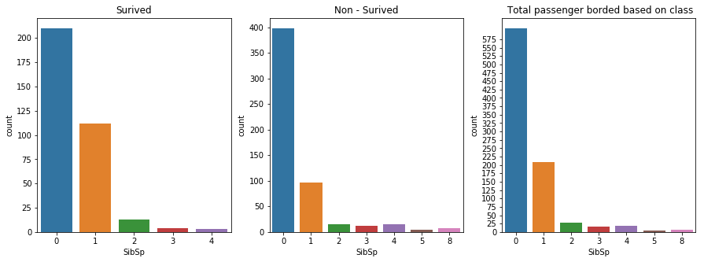

```python
f,ax=plt.subplots(1,3,figsize=(15,5))
sns.countplot("SibSp",data=data[data.Survived==1],ax=ax[0])
ax[0].set_title("Surived")
sns.countplot("SibSp",data=data[data.Survived==0],ax=ax[1])
ax[1].set_title("Non - Surived")
sns.countplot("SibSp",data=data,ax=ax[2])
ax[2].set_title(" Total passenger borded based on class")
ax[2].set_yticks(range(0,600,25))
```

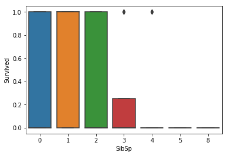

```python
sns.boxplot("SibSp","Survived",data=data)
```

```python
pd.crosstab(data.SibSp,[data.Pclass,data.Survived],margins=True).style.background_gradient(cmap='summer_r')
```

| Pclass Survived SibSp | 1 0 | 1 | 2 0 | 2 1 | 3 0 | 3 1 | All |
| --- | --- | --- | --- | --- | --- | --- | --- |
| 0 | 60 | 77 | 70 | 50 | 268 | 83 | 608 |
| 1 | 18 | 53 | 23 | 32 | 56 | 27 | 209 |
| 2 | 1 | 4 | 4 | 4 | 10 | 5 | 28 |
| 3 | 1 | 2 | 0 | 1 | 11 | 1 | 16 |
| 4 | 0 | 0 | 0 | 0 | 15 | 3 | 18 |
| 5 | 0 | 0 | 0 | 0 | 5 | 0 | 5 |
| 8 | 0 | 0 | 0 | 0 | 7 | 0 | 7 |
| All | 80 | 136 | 97 | 87 | 372 | 119 | 891 |

### Observations:

The reason is Pclass. The crosstab shows that Person with SibSp>3 were all in Pclass3. It is imminent that all the large families in Pclass3(>3) died.

### Parch

```python
pd.crosstab(data.Parch, data.Survived,margins=True).style.background_gradient(cmap='summer_r')
```

| Survived Parch | 0 | 1 | All |
| --- | --- | --- | --- |
| 0 | 445 | 233 | 678 |
| 1 | 53 | 65 | 118 |
| 2 | 40 | 40 | 80 |
| 3 | 2 | 3 | 5 |
| 4 | 4 | 0 | 4 |
| 5 | 4 | 1 | 5 |
| 6 | 1 | 0 | 1 |
| All | 549 | 342 | 891 |

```python
pd.crosstab(data.Parch, [data.Pclass,data.Survived],margins=True).style.background_gradient(cmap='summer_r')
```

| Pclass Survived Parch | 1 0 | 1 | 2 0 | 2 1 | 3 0 | 3 1 | All |
| --- | --- | --- | --- | --- | --- | --- | --- |
| 0 | 64 | 99 | 86 | 48 | 295 | 86 | 678 |
| 1 | 10 | 21 | 8 | 24 | 35 | 20 | 118 |
| 2 | 5 | 16 | 3 | 13 | 32 | 11 | 80 |
| 3 | 0 | 0 | 0 | 2 | 2 | 1 | 5 |
| 4 | 1 | 0 | 0 | 0 | 3 | 0 | 4 |
| 5 | 0 | 0 | 0 | 0 | 4 | 1 | 5 |
| 6 | 0 | 0 | 0 | 0 | 1 | 0 | 1 |
| All | 80 | 136 | 97 | 87 | 372 | 119 | 891 |

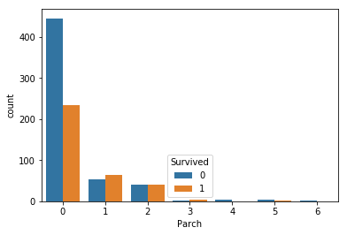

```python
sns.countplot("Parch",hue="Survived",data=data)
```

### Observations

Here too the results are quite similar. Passengers with their parents onboard have greater chance of survival. It however reduces as the number goes up.

The chances of survival is good for somebody who has 1-3 parents on the ship. Being alone also proves to be fatal and the chances for survival decreases when somebody has >4 parents on the ship.

### Fare--> Continous Feature

```python
print "Hightes Fare : ", data.Fare.max()
print "Min Fare : ", data.Fare.min()
print "Average Fare : ", data.Fare.mean()
print "missing count : ", data.Fare.isnull().sum()
```

```
Hightes Fare :  512.3292
Min Fare :  0.0
Average Fare :  32.2042079686
missing count :  0
```

```python
data.groupby(data.Fare==0).count()
```

| Fare | PassengerId | Survived | Pclass | Name | Sex | Age | SibSp | Parch | Ticket | Fare | Cabin | Embarked | Initial |
| --- | --- | --- | --- | --- | --- | --- | --- | --- | --- | --- | --- | --- | --- |
| False | 876 | 876 | 876 | 876 | 876 | 876 | 876 | 876 | 876 | 876 | 201 | 876 | 876 |
| True | 15 | 15 | 15 | 15 | 15 | 15 | 15 | 15 | 15 | 15 | 3 | 15 | 15 |

```python
data[data.Fare==0].groupby("Pclass").count()
```

| Pclass | PassengerId | Survived | Name | Sex | Age | SibSp | Parch | Ticket | Fare | Cabin | Embarked | Initial |
| --- | --- | --- | --- | --- | --- | --- | --- | --- | --- | --- | --- | --- |
| 1 | 5 | 5 | 5 | 5 | 5 | 5 | 5 | 5 | 5 | 3 | 5 | 5 |
| 2 | 6 | 6 | 6 | 6 | 6 | 6 | 6 | 6 | 6 | 0 | 6 | 6 |
| 3 | 4 | 4 | 4 | 4 | 4 | 4 | 4 | 4 | 4 | 0 | 4 | 4 |

The lowest fare is 0.0. Wow!! a free luxorious ride.

[figure not shown]

```python
sns.countplot("Fare",data=data[data.Pclass==1])
```

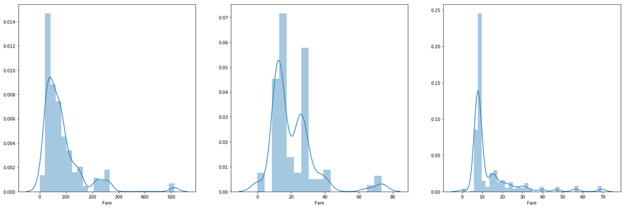

```python
f,ax=plt.subplots(1,3,figsize=(25,8))
sns.distplot(data[data.Pclass==1].Fare,ax=ax[0])
sns.distplot(data[data.Pclass==2].Fare,ax=ax[1])
sns.distplot(data[data.Pclass==3].Fare,ax=ax[2])
```

There looks to be a large distribution in the fares of Passengers in Pclass1 and this distribution goes on decreasing as the standards reduces. As this is also continous, we can convert into discrete values by using binning.

### Observations in a Nutshell for all features:

Sex: The chance of survival for women is high as compared to men.

Pclass:There is a visible trend that being a 1st class passenger gives you better chances of survival. The survival rate for Pclass3 is very low. For women, the chance of survival from Pclass1 is almost 1 and is high too for those from Pclass2. Money Wins!!!.

Age: Children less than 5-10 years do have a high chance of survival. Passengers between age group 15 to 35 died a lot.

Parch+SibSp: Having 1-2 siblings,spouse on board or 1-3 Parents shows a greater chance of probablity rather than being alone or having a large family travelling with you.

### Correlation Between The Features

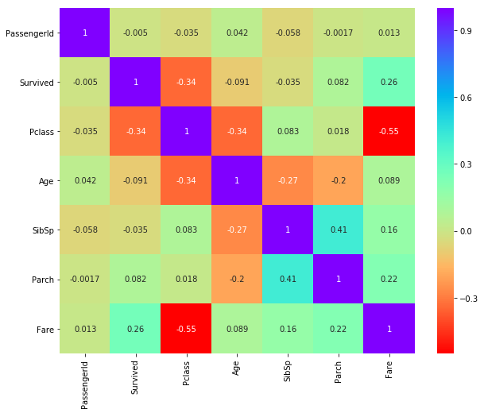

```python
sns.heatmap(data.corr(),cmap='rainbow_r',annot=True)
fig=plt.gcf()
fig.set_size_inches(10,8)
```

### Interpreting The Heatmap

The first thing to note is that only the numeric features are compared as it is obvious that we cannot correlate between alphabets or strings. Before understanding the plot, let us see what exactly correlation is.

POSITIVE CORRELATION: If an increase in feature A leads to increase in feature B, then they are positively correlated. A value 1 means perfect positive correlation.

NEGATIVE CORRELATION: If an increase in feature A leads to decrease in feature B, then they are negatively correlated. A value -1 means perfect negative correlation.

Now lets say that two features are highly or perfectly correlated, so the increase in one leads to increase in the other. This means that both the features are containing highly similar information and there is very little or no variance in information. This is known as MultiColinearity as both of them contains almost the same information.

So do you think we should use both of them as one of them is redundant. While making or training models, we should try to eliminate redundant features as it reduces training time and many such advantages.

### Part2: Feature Engineering and Data Cleaning

Now what is Feature Engineering?

Whenever we are given a dataset with features, it is not necessary that all the features will be important. There maybe be many redundant features which should be eliminated. Also we can get or add new features by observing or extracting information from other features.

An example would be getting the Initals feature using the Name Feature. Lets see if we can get any new features and eliminate a few. Also we will tranform the existing relevant features to suitable form for Predictive Modeling.

### Age_band

Problem With Age Feature:

As I have mentioned earlier that Age is a continous feature, there is a problem with Continous Variables in Machine Learning Models.

Eg:If I say to group or arrange Sports Person by Sex, We can easily segregate them by Male and Female. Now if I say to group them by their Age, then how would you do it? If there are 30 Persons, there may be 30 age values. Now this is problematic.

We need to convert these continous values into categorical values by either Binning or Normalisation. I will be using binning i.e group a range of ages into a single bin or assign them a single value.

Okay so the maximum age of a passenger was 80. So lets divide the range from 0-80 into 5 bins. So 80/5=16. So bins of size 16.

```python
data.Age_band=0
data.loc[(data.Age<=16),"Age_band"]=1
data.loc[(data.Age>16)&(data.Age<=32),"Age_band"]=2
data.loc[(data.Age>32)&(data.Age<=48),"Age_band"]=3
data.loc[(data.Age>48)&(data.Age<=64),"Age_band"]=4
data.loc[(data.Age>64)&(data.Age<=80),"Age_band"]=5
```

```python
data.head()
```

|  | PassengerId | Survived | Pclass | Name | Sex | Age | SibSp | Parch | Ticket | Fare | Cabin | Embarked | Initial | Age_band |
| --- | --- | --- | --- | --- | --- | --- | --- | --- | --- | --- | --- | --- | --- | --- |
| 0 | 1 | 0 | 3 | Braund, Mr. Owen Harris | male | 22.0 | 1 | 0 | A/5 21171 | 7.2500 | NaN | S | Mr | 2.0 |
| 1 | 2 | 1 | 1 | Cumings, Mrs. John Bradley (Florence Briggs Th... | female | 38.0 | 1 | 0 | PC 17599 | 71.2833 | C85 | C | Mrs | 3.0 |
| 2 | 3 | 1 | 3 | Heikkinen, Miss. Laina | female | 26.0 | 0 | 0 | STON/O2. 3101282 | 7.9250 | NaN | S | Miss | 2.0 |
| 3 | 4 | 1 | 1 | Futrelle, Mrs. Jacques Heath (Lily May Peel) | female | 35.0 | 1 | 0 | 113803 | 53.1000 | C123 | S | Mrs | 3.0 |
| 4 | 5 | 0 | 3 | Allen, Mr. William Henry | male | 35.0 | 0 | 0 | 373450 | 8.0500 | NaN | S | Mr | 3.0 |

```
Text(0.5,1,u'Total passenger based on Age Band')
```

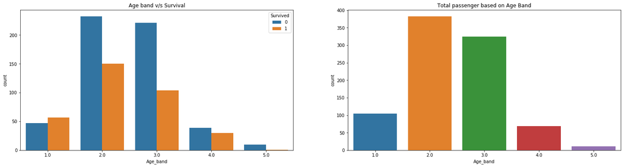

```python
f,ax=plt.subplots(1,2,figsize=(25,6))
sns.countplot("Age_band",data=data,hue="Survived",ax=ax[0])
ax[0].set_title("Age band v/s Survival")
sns.countplot("Age_band",data=data,ax=ax[1])
ax[1].set_title("Total passenger based on Age Band")
```

```python
data["Age_band"].value_counts().to_frame().style.background_gradient(cmap='summer')#checking the number of passenegers in each band
```

|  | Age_band |
| --- | --- |
| 2.0 | 382 |
| 3.0 | 325 |
| 1.0 | 104 |
| 4.0 | 69 |
| 5.0 | 11 |

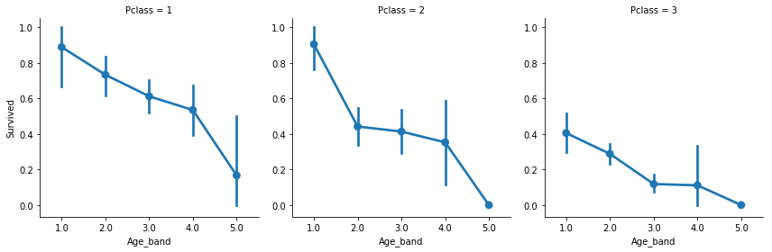

```python
sns.factorplot("Age_band","Survived",data=data,col="Pclass")
```

True that..the survival rate decreases as the age increases irrespective of the Pclass.

### Family_Size and Alone

At this point, we can create a new feature called "Family_size" and "Alone" and analyse it. This feature is the summation of Parch and SibSp. It gives us a combined data so that we can check if survival rate have anything to do with family size of the passengers. Alone will denote whether a passenger is alone or not.

```python
data['Family_Size']=0
data['Family_Size']=data.SibSp+data.Parch
```

```python
data['Alone']=0
data.loc[(data.Family_Size==0), 'Alone']=1
```

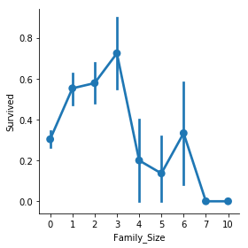

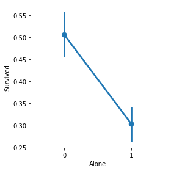

```python
sns.factorplot("Family_Size","Survived", data=data)
sns.factorplot("Alone","Survived", data=data)
```

Family_Size=0 means that the passeneger is alone. Clearly, if you are alone or family_size=0,then chances for survival is very low. For family size > 4,the chances decrease too. This also looks to be an important feature for the model. Lets examine this further.

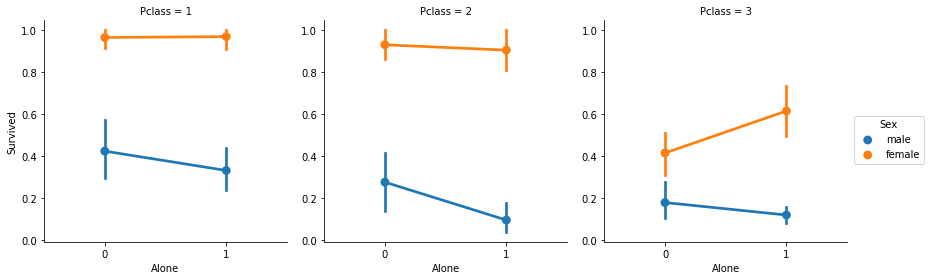

```python
sns.factorplot('Alone','Survived',data=data,hue='Sex',col='Pclass')
plt.show()
```

It is visible that being alone is harmful irrespective of Sex or Pclass except for Pclass3 where the chances of females who are alone is high than those with family.

### Fare_Range

Since fare is also a continous feature, we need to convert it into ordinal value. For this we will use pandas.qcut.

So what qcut does is it splits or arranges the values according the number of bins we have passed. So if we pass for 5 bins, it will arrange the values equally spaced into 5 seperate bins or value ranges.

```python
data["Fare_Range"]=pd.qcut(data.Fare,4)
```

```python
data.groupby(['Fare_Range'])["Survived"].mean()
```

```
Fare_Range
(-0.001, 7.91]     0.197309
(7.91, 14.454]     0.303571
(14.454, 31.0]     0.454955
(31.0, 512.329]    0.581081
Name: Survived, dtype: float64
```

```python
data.Fare_Range.value_counts()
```

```
(7.91, 14.454]     224
(-0.001, 7.91]     223
(31.0, 512.329]    222
(14.454, 31.0]     222
Name: Fare_Range, dtype: int64
```

As discussed above, we can clearly see that as the fare_range increases, the chances of survival increases.

Now we cannot pass the Fare_Range values as it is. We should convert it into singleton values same as we did in Age_Band

```python
data['Fare_cat']=0
data.loc[data['Fare']<=7.91,'Fare_cat']=0
data.loc[(data['Fare']>7.91)&(data['Fare']<=14.454),'Fare_cat']=1
data.loc[(data['Fare']>14.454)&(data['Fare']<=31),'Fare_cat']=2
data.loc[(data['Fare']>31)&(data['Fare']<=513),'Fare_cat']=3
```

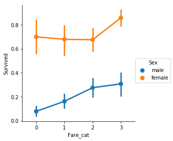

```python
sns.factorplot('Fare_cat','Survived',data=data,hue='Sex')
plt.show()
```

Clearly, as the Fare_cat increases, the survival chances increases. This feature may become an important feature during modeling along with the Sex.

### Converting String Values into Numeric

Since we cannot pass strings to a machine learning model, we need to convert features loke Sex, Embarked, etc into numeric values.

```python
data['Sex'].replace(['male','female'],[0,1],inplace=True)
data['Embarked'].replace(['S','C','Q'],[0,1,2],inplace=True)
data['Initial'].replace(['Mr','Mrs','Miss','Master','Other'],[0,1,2,3,4],inplace=True)
```

Dropping UnNeeded Features

Name--> We don't need name feature as it cannot be converted into any categorical value.

Age--> We have the Age_band feature, so no need of this.

Ticket--> It is any random string that cannot be categorised.

Fare--> We have the Fare_cat feature, so unneeded

Cabin--> A lot of NaN values and also many passengers have multiple cabins. So this is a useless feature.

Fare_Range--> We have the fare_cat feature.

PassengerId--> Cannot be categorised.

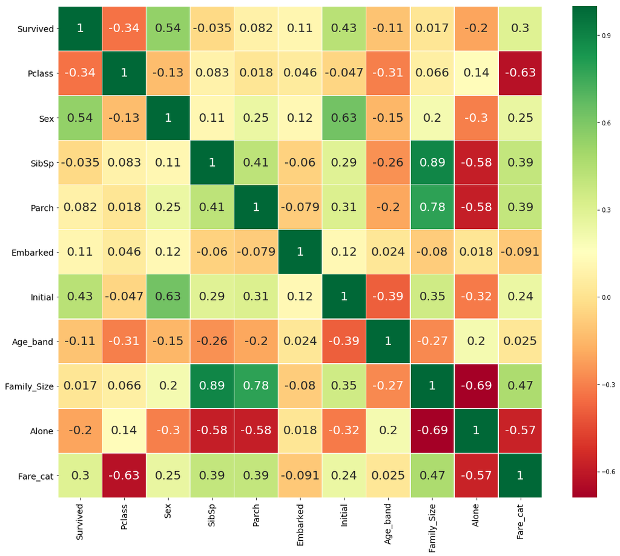

```python
data.drop(['Name','Age','Ticket','Fare','Cabin','Fare_Range','PassengerId'],axis=1,inplace=True)
sns.heatmap(data.corr(),annot=True,cmap='RdYlGn',linewidths=0.2,annot_kws={'size':20})
fig=plt.gcf()
fig.set_size_inches(18,15)
plt.xticks(fontsize=14)
plt.yticks(fontsize=14)
plt.show()
```

Now the above correlation plot, we can see some positively related features. Some of them being SibSp andd Family_Size and Parch and Family_Size and some negative ones like Alone and Family_Size.

### Part3: Predictive Modeling

We have gained some insights from the EDA part. But with that, we cannot accurately predict or tell whether a passenger will survive or die. So now we will predict the whether the Passenger will survive or not using some great Classification Algorithms.Following are the algorithms I will use to make the model:

1)Logistic Regression

2)Support Vector Machines(Linear and radial)

3)Random Forest

4)K-Nearest Neighbours

5)Naive Bayes

6)Decision Tree

7)Logistic Regression

```python
from sklearn import svm
from sklearn.linear_model import LogisticRegression
from sklearn.neighbors import KNeighborsClassifier
from sklearn.naive_bayes import GaussianNB
from sklearn.tree import DecisionTreeClassifier

from sklearn.ensemble import RandomForestClassifier

from sklearn.cross_validation import train_test_split
from sklearn import metrics
```

```python
feature_col=data.columns.difference(data["Survived"])
feature_col
```

```
Index([u'Age_band', u'Alone', u'Embarked', u'Family_Size', u'Fare_cat',
       u'Initial', u'Parch', u'Pclass', u'Sex', u'SibSp', u'Survived'],
      dtype='object')
```

```python
train,test=train_test_split(data,test_size=0.3,random_state=0,stratify=data['Survived'])
train_X=train[train.columns[1:]]
train_Y=train[train.columns[:1]]
test_X=test[test.columns[1:]]
test_Y=test[test.columns[:1]]
X=data[data.columns[1:]]
Y=data['Survived']
```

Radial Support Vector Machines(rbf-SVM

```python
abc=["rbf","linear"]
for i in abc:
    model=svm.SVC(kernel=i,C=1,gamma=0.1)
    model.fit(train_X,train_Y)
    pred_y=model.predict(test_X)
    print "Accuracy score for ", i, "SVM :", metrics.accuracy_score(test_Y,pred_y)
```

```
Accuracy score for  rbf SVM : 0.835820895522
Accuracy score for  linear SVM : 0.798507462687
```

```python
model = LogisticRegression()
model.fit(train_X,train_Y)
prediction3=model.predict(test_X)
print('The accuracy of the Logistic Regression is',metrics.accuracy_score(prediction3,test_Y))
```

```
('The accuracy of the Logistic Regression is', 0.81716417910447758)
```

```python
model=DecisionTreeClassifier()
model.fit(train_X,train_Y)
prediction4=model.predict(test_X)
print('The accuracy of the Decision Tree is',metrics.accuracy_score(prediction4,test_Y))
```

```
('The accuracy of the Decision Tree is', 0.80597014925373134)
```

```python
model=KNeighborsClassifier()
model.fit(train_X,train_Y)
prediction5=model.predict(test_X)
print('The accuracy of the KNN is',metrics.accuracy_score(prediction5,test_Y))
```

```
('The accuracy of the KNN is', 0.83208955223880599)
```

### KNN

Now the accuracy for the KNN model changes as we change the values for n_neighbours attribute. The default value is 5. Lets check the accuracies over various values of n_neighbours.

```python
a_index=list(range(1,11))
a=pd.Series()
```

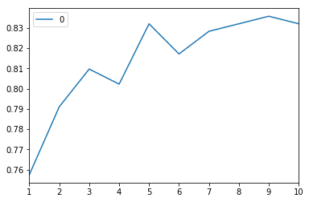

```python
a1=[]
for i in range(1,11):
    model=KNeighborsClassifier(n_neighbors=i)
    model.fit(train_X,train_Y)
    pred_y=model.predict(test_X)
    a1.append(metrics.accuracy_score(test_Y,pred_y))
a1=pd.DataFrame(a1,a_index)
#a1.columns="KNN_Accuracy_Score"

a1.plot()
```

```python
a1
```

|  | 0 |
| --- | --- |
| 1 | 0.757463 |
| 2 | 0.791045 |
| 3 | 0.809701 |
| 4 | 0.802239 |
| 5 | 0.832090 |
| 6 | 0.817164 |
| 7 | 0.828358 |
| 8 | 0.832090 |
| 9 | 0.835821 |
| 10 | 0.832090 |

### Gaussian Naive Bayes

```python
model=GaussianNB()
model.fit(train_X,train_Y)
prediction6=model.predict(test_X)
print('The accuracy of the NaiveBayes is',metrics.accuracy_score(prediction6,test_Y))
```

```
('The accuracy of the NaiveBayes is', 0.81343283582089554)
```

### Random Forests

```python
model=RandomForestClassifier(n_estimators=100)
model.fit(train_X,train_Y)
prediction7=model.predict(test_X)
print('The accuracy of the Random Forests is',metrics.accuracy_score(prediction7,test_Y))
```

```
('The accuracy of the Random Forests is', 0.81343283582089554)
```